# Florida Aviation Elevation Analysis

2026-01-30

## Exploratory Descriptive Statistics

```r
setwd("C:/_Assignment1") aviation <- read.csv("aviationfacilities.csv", header = TRUE)
str(aviation)
```

```
## 'data.frame': 19707 obs. of 90 variables:
## $ EFF_DATE : chr "2025/12/25" "2025/12/25" "2025/12/25" "2025/12/25" ...
## $ SITE_NO : num 103 106 108 110 110 ...
## $ SITE_TYPE_CODE : chr "A" "A" "A" "A" ...
## $ STATE_CODE : chr "AL" "AL" "AL" "AL" ...
## $ ARPT_ID : chr "0J0" "2A8" "AL03" "EET" ...
## $ CITY : chr "ABBEVILLE" "ADDISON" "AKRON" "ALABASTER" ...
## $ COUNTRY_CODE : chr "US" "US" "US" "US" ...
## $ REGION_CODE : chr "ASO" "ASO" "ASO" "ASO" ...
## $ ADO_CODE : chr "JAN" "JAN" "JAN" "JAN" ...
## $ STATE_NAME : chr "ALABAMA" "ALABAMA" "ALABAMA" "ALABAMA" ...
## $ COUNTY_NAME : chr "HENRY" "WINSTON" "HALE" "SHELBY" ...
## $ COUNTY_ASSOC_STATE : chr "AL" "AL" "AL" "AL" ...
## $ ARPT_NAME : chr "ABBEVILLE MUNI" "ADDISON MUNI" "STRICKLAND/SMALLEY FLD" "SHELBY COUNTY" ...
## $ OWNERSHIP_TYPE_CODE : chr "PU" "PU" "PR" "PU" ...
```

[output cut: 76 more lines]

```r
aviation_fl <- subset(aviation, STATE_CODE == "FL")
```

```r
summary(aviation_fl$ELEV)
```

```
## Min. 1st Qu. Median Mean 3rd Qu. Max. ## 0.00 19.45 55.00 69.11 98.00 709.00
```

```r
mean_fl <- mean(aviation_fl$ELEV, na.rm = TRUE)
median_fl <- median(aviation_fl$ELEV, na.rm = TRUE)
sd_fl <- sd(aviation_fl$ELEV, na.rm = TRUE)
range_fl <- range(aviation_fl$ELEV, na.rm = TRUE)
iqr_fl <- IQR(aviation_fl$ELEV, na.rm = TRUE) mean_fl
```

```
## [1] 69.10834
```

```r
median_fl
```

```
## [1] 55
```

```r
sd_fl
```

```
## [1] 64.22694
```

```r
range_fl
```

```
## [1] 0 709
```

```r
iqr_fl
```

```
## [1] 78.55
```

## Key Statistical Findings: For aviation facilities in Florida, the mean elevation is 69.1 m and the median elevation is 55.0 m. The elevation ranges from 0.0 m to 709.0 m, with an interquartile range of 78.6 m and a standard deviation of 64.2 m.

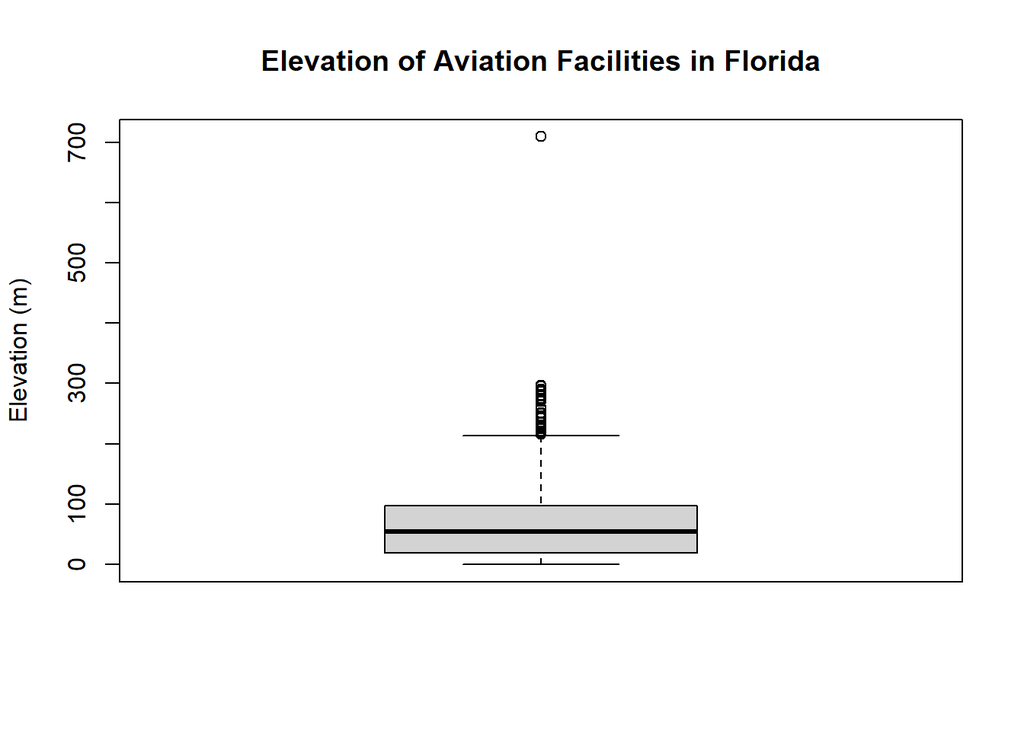

```r
boxplot(aviation_fl$ELEV, main = "Elevation of Aviation Facilities in Florida", ylab = "Elevation (m)")
```

## Interpretation: As shown in the graph, there are many extreme data points. If the mean is used, it will be affected by these extreme data points, the median is a more appropriate measure of central tendency for this dataset.

## Spatial Center Mapping

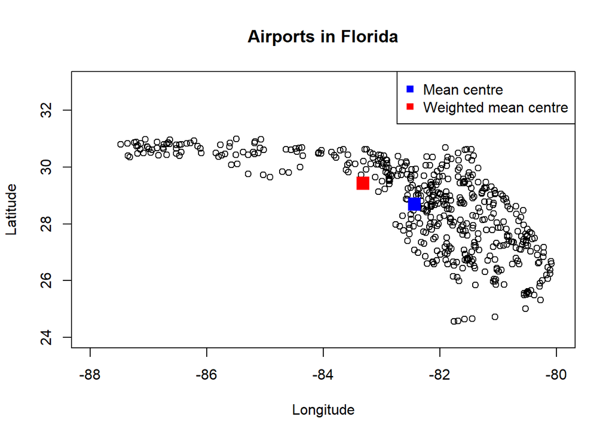

```r
FL_airports <- aviation_fl[ aviation_fl$SITE_TYPE_CODE == "A", ] plot( FL_airports$LONG_DECIMAL, FL_airports$LAT_DECIMAL, xlab = "Longitude", ylab = "Latitude", main = "Airports in Florida", xlim = c(-88, -80), ylim = c(24, 33)
) n <- nrow(FL_airports)[1] mc_x <- sum(FL_airports$LONG_DECIMAL) / n
mc_y <- sum(FL_airports$LAT_DECIMAL) / n points(mc_x, mc_y, pch = 15, cex = 2, col = "blue") wmc_x <- sum(as.numeric(FL_airports$ELEV * FL_airports$LONG_DECIMAL), na.rm = TRUE) / sum(FL_airports$ELEV, na.rm = TRUE) wmc_y <- sum(as.numeric(FL_airports$ELEV * FL_airports$LAT_DECIMAL), na.rm = TRUE) / sum(FL_airports$ELEV, na.rm = TRUE) points(wmc_x, wmc_y, pch = 15, cex = 2, col = "red") legend("topright", legend = c("Mean centre", "Weighted mean centre"), pch = c(15, 15), col = c("blue", "red"))
```

## Code Notes:

1. `aviationfacilities <- read.csv("aviationfacilities.csv", sep = ',', header = TRUE)`
2. `plot(FL_airports$LONG_DECIMAL, FL_airports$LAT_DECIMAL, xlab="Longitude", ylab="Latitude", main = "Airports in Florida", xlim=c(-88, -80), ylim=c(24, 33))`
3. `n<-nrow(FL_airports[1])`
4. `mc_x<-sum(FL_airports$LONG_DECIMAL)/n` `mc_y<-sum(FL_airports$LAT_DECIMAL)/n`
5. `points(mc_x,mc_y,'p',pch=15,cex=2,col="blue")`
6. `wmc_x <- sum(as.numeric(FL_airports$ELEV * FL_airports$LONG_DECIMAL), na.rm = TRUE) / sum(FL_airports$ELEV, na.rm = TRUE)` `wmc_y <- sum(as.numeric(FL_airports$ELEV * FL_airports$LAT_DECIMAL), na.rm = TRUE) / sum(FL_airports$ELEV, na.rm = TRUE)`
7. `points(wmc_x, wmc_y,'p',pch=15,cex=2,col='red')`
8. `legend("topright", legend = c("Mean centre", "Weighted mean centre"), pch = c(15,15), col = c("blue","red"))`

##(a): This line reads the CSV file named aviationfacilities.csv into R and stores it as a data frame. The sep=“,” specifies that the values in the file are separated by commas, and the header=TRUE indicates that the first row of the file contains column names.

##(b): This command creates a scatter plot that show the spatial distribution of airports in Florida.The x-axis represents longitude and the y-axis represents latitude.The command xlab and ylab label the axes, and the command main give the plot title. The xlim and ylim command set the longitude and latitude ranges to focus the map on Florida.

##(c): This line calculates the total number of airports in Florida by counting the number of rows in the FL_airports data frame.

##(d): These two lines calculate the mean centre of the airport locations. Adding all longitude and latitude values together and then dividing by the total number of airports to get the average longitude (mc_x) and average latitude (mc_y).

##(e): This command adds the mean centre to the plot. The command pch=15 specifies a square plotting symbol, cex=2 define the symbol size, and col=“blue” sets the colour of the mean centre point.

##(f): This line calculates the weighted mean longitude of the airports by using the elevation as the weighting factor. Every longitude value is multiplied by its corresponding elevation, and summed, and then divided by the sum of all elevation values. The command na.rm=TRUE ensures that missing values will be ignored during the calculation.

##(g): This command adds the weighted mean centre to the plot. The command pch=15 specifies a square plotting symbol, cex=2 define the symbol size, and col=“red” sets the colour of the weighted mean centre point.

##(h): This command adds a legend in different color to the top-right corner of the plot. The pch and col ensure that the symbols and colours in the legend match those used in the plot.

##Question 10:The mean centre represents the average spatial location of airports in Florida. This point is the geometric center of all airports in Florida and is not affected by airport weights. The weighted mean incorporates elevation, and the weighted mean centre shifts to northward. This means airports with higher elevations are concentrated in northern Florida. The weighted mean centre consider both spatial and topographical attributes.

## Part 3C. Create and Visualize Subsets

##Question 11:

```r
summary(FL_airports$ELEV)
```

```
## Min. 1st Qu. Median Mean 3rd Qu. Max. ## 3.00 23.00 65.00 73.93 102.00 295.00
```

```r
sm_elev <- subset(FL_airports, FL_airports$ELEV < 65)
lrg_elev <- subset(FL_airports, FL_airports$ELEV >= 65)
```

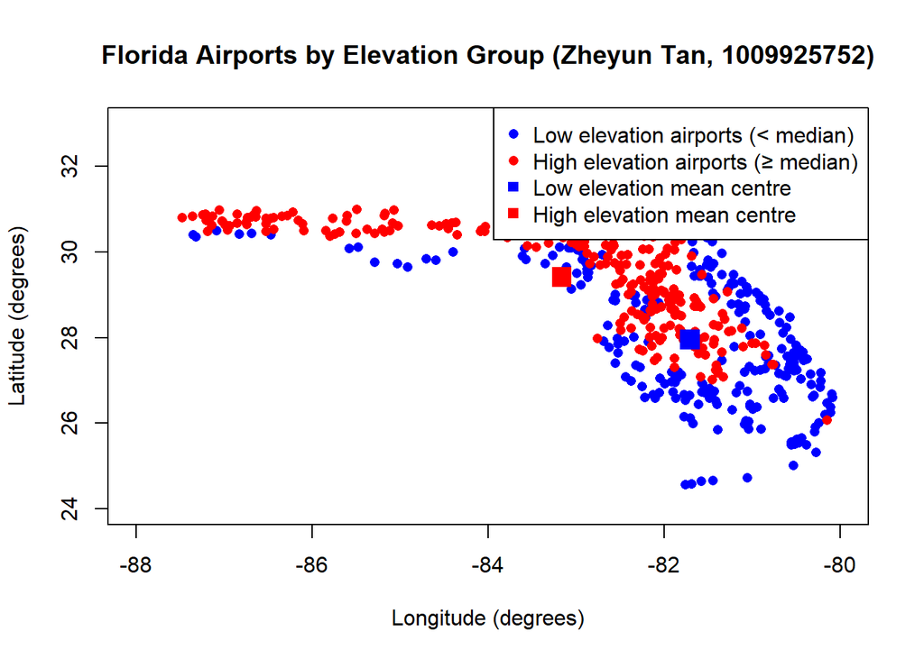

```r
plot( sm_elev$LONG_DECIMAL, sm_elev$LAT_DECIMAL, col = "blue", pch = 16, xlab = "Longitude (degrees)", ylab = "Latitude (degrees)", main = "Florida Airports by Elevation Group (, )", xlim = c(-88, -80), ylim = c(24, 33)
) points( lrg_elev$LONG_DECIMAL, lrg_elev$LAT_DECIMAL, col = "red", pch = 16
)
sm_mc_x <- sum(sm_elev$LONG_DECIMAL) / nrow(sm_elev)
sm_mc_y <- sum(sm_elev$LAT_DECIMAL) / nrow(sm_elev) points(sm_mc_x, sm_mc_y, pch = 15, cex = 2, col = "blue") lrg_mc_x <- sum(lrg_elev$LONG_DECIMAL) / nrow(lrg_elev)
lrg_mc_y <- sum(lrg_elev$LAT_DECIMAL) / nrow(lrg_elev) points(lrg_mc_x, lrg_mc_y, pch = 15, cex = 2, col = "red") legend( "topright", legend = c( "Low elevation airports (< median)", "High elevation airports (≥ median)", "Low elevation mean centre", "High elevation mean centre" ), col = c("blue", "red", "blue", "red"), pch = c(16, 16, 15, 15)
)
```

##Part 3D. Dispersion of Subsets

```r
sd_lon_all <- sd(FL_airports$LONG_DECIMAL)
sd_lat_all <- sd(FL_airports$LAT_DECIMAL) sd_lon_all
```

```
## [1] 1.785058
```

```r
sd_lat_all
```

```
## [1] 1.542124
```

```r
sd_lon_sm <- sd(sm_elev$LONG_DECIMAL)
sd_lat_sm <- sd(sm_elev$LAT_DECIMAL) sd_lon_sm
```

```
## [1] 1.343617
```

```r
sd_lat_sm
```

```
## [1] 1.533126
```

```r
sd_lon_lrg <- sd(lrg_elev$LONG_DECIMAL)
sd_lat_lrg <- sd(lrg_elev$LAT_DECIMAL) sd_lon_lrg
```

```
## [1] 1.872165
```

```r
sd_lat_lrg
```

```
## [1] 1.15742
```

##Question 12: Data shows that the standard deviation of longitude (1.79°) is greater than the standard deviation of latitude (1.54°). This means that the east-west dispersion is greater than the north-south dispersion, and due to Florida’s elongated shape. For low-altitude airports, the north-south dispersion (1.53°) is slightly greater than the east-west dispersion (1.34°), this means that most low-altitude airports are located in the south and coastal areas. For high-altitude airports, the east-west dispersion (1.87°) is much greater than the north-south dispersion (1.16°), ans this means that most high-altitude airports are located in the north and inland areas.